## Assignment 6

#### Due Sunday, March 26, 11:59 PM CT

### Preliminaries

- Directories
  - COURSE/homework/
  - COURSE/homework/hw06/
  - COURSE/data/
  - COURSE/scripts/
- Files
  - COURSE/homework/hw06/hw06.Rmd
  - COURSE/data/exoplanets-clean-through-2022.csv
  - COURSE/data/wordle.csv
  - COURSE/scripts/viridis.R

### Aims

- Practice strings and regular expressions

### Problems

Problems 1–4 are based on a data frame with the names of built-in R colors.

```r
df_colors = tibble(color = colors()) %>%
  mutate(index = row_number(), .before = color)
```

1. Create a data frame with the names of all colors whose names are exactly 7 characters long. Print a summary of this data frame with the number of colors and the first and last alphabetically in the list.

#### Solution

```r
prob1 = df_colors %>%
  filter(str_length(color) == 7) %>%
  arrange(color)

prob1 %>%
  summarize(n = n(),
            first = min(color),
            last = max(color))
```

```
## # A tibble: 1 × 3
##       n first   last
##   <int> <chr>   <chr>
## 1    46 bisque1 yellow4
```

2. How many of the previous color names contain no digits? Create a second data frame which eliminates the rows from your solution to the previous problem any color names which contain a digit. Print a summary of this data frame with the number of colors and the first and last alphabetically in the list.

#### Solution

```r
prob2 = prob1 %>%
  filter(!str_detect(color, "[:digit:]"))

prob2 %>%
  summarize(n = n(),
            first = min(color),
            last = max(color))
```

```
## # A tibble: 1 × 3
##       n first   last
##   <int> <chr>   <chr>
## 1     8 darkred thistle
```

3. Find all colors which contain consecutive letters “e”. Print a summary with a count of how many such colors there are and the first and last alphabetically.

#### Solution

```r
prob3 = df_colors %>%
  filter(str_detect(color, "ee")) %>%
  arrange(color)

prob3 %>%
  summarize(n = n(),
            first = min(color),
            last = max(color))
```

```
## # A tibble: 1 × 3
##       n first     last
##   <int> <chr>     <chr>
## 1    60 darkgreen yellowgreen
```

4. Find all color names which contain any consecutive identical letters. Create a data frame with these colors.
- Print the first ten rows of this data frame
- Tabulate how often each letter is used in a consecutive letter pair and print out this table arranged in descending order of the counts.
  - *It is okay to count only the first letter pair in words with more than one such pair.*
  - *Extra brownie points if you correctly count multiple consecutive letter pairs when more than one exist in a name.*
- Identify the three color names which have a distinct pair of consecutive identical letters. (These are the only color names which use the given letter pair.)

#### Solution

```r
## The variable `consecutive` only contain the first consecutive pair and does not count subsequent pairs such as in the name "deeppink"
prob4 = df_colors %>%
  filter(str_detect(color, "([:alpha:])\\1")) %>%
  mutate(consecutive = str_extract(color, "([:alpha:])\\1"))

prob4 %>%
  print(n = 10)
```

```
## # A tibble: 104 × 3
##    index color           consecutive
##    <int> <chr>           <chr>
##  1    37 burlywood       oo
##  2    38 burlywood1      oo
##  3    39 burlywood2      oo
##  4    40 burlywood3      oo
##  5    41 burlywood4      oo
##  6    81 darkgreen       ee
##  7    83 darkkhaki       kk
##  8    85 darkolivegreen  ee
##  9    86 darkolivegreen1 ee
## 10    87 darkolivegreen2 ee
## # … with 94 more rows
```

```r
prob4 %>%
  count(consecutive) %>%
  arrange(desc(n))
```

[output not shown]

```r
prob4 %>%
  filter(consecutive == "cc" |
           consecutive == "dd" |
           consecutive == "kk")
```

```
## # A tibble: 3 × 3
##   index color       consecutive
##   <int> <chr>       <chr>
## 1    83 darkkhaki   kk
## 2   484 moccasin    cc
## 3   567 saddlebrown dd
```

#### Solution which accounts for multiple occurrences

```r
multiple_pairs = df_colors %>%
  filter(str_detect(color, "([:alpha])\\1.*([:alpha:])\\2"))

multiple_pairs
```

```
## # A tibble: 1 × 2
##   index color
##   <int> <chr>
## 1   657 yellowgreen
```

```r
three_pairs = df_colors %>%
  filter(str_detect(color, "([:alpha:])\\1.*([:alpha:])\\2.*([:alpha:])\\3"))

three_pairs
```

```
## # A tibble: 0 × 2
## # … with 2 variables: index <int>, color <chr>
```

- Here is a modification of the solution which extracts the first and second consecutive identical letter pairs from each word and then counts the pairs in total.
- Note the tricky regular expression for `consecutive 2`, `"([:alpha:])\\1.*(([:alpha:])\\3)"`.
  - The first group is `([:alpha:])` and is the first letter of a consecutive identical letter pair.
  - After the first group is `.*` which repeats any character 0 or more times
  - The second group is `(([:alpha:])\\3)` which contains within it the third group `([:alpha:])`.
  - The third group is the first letter of the second consecutive identical letter pair.
  - The second group is both letters of the second consecutive identical letter pair.
  - The order of the groups is by the order of the left parenthesis, `(`.
- We use the `group` argument of `str_extract()` to extract the second group of the color name which is the full pair of identical consecutive letters

```r
prob4_multiple = df_colors %>%
  mutate(
    consecutive1 = str_extract(
      color, "([:alpha:])\\1"),
    consecutive2 = str_extract(
      color,
      "([:alpha:])\\1.*(([:alpha:])\\3)",
      group = 2)) %>%
  drop_na(consecutive1)
```

- To count occurrences, I will use `pivot_longer()` to use multiple rows when a word has multiple letter pairs and then drop the missing values.

```r
## corrected counts to account for multiple pairs in the same color name
count4_corrected = prob4_multiple %>%
  pivot_longer(consecutive1:consecutive2,
               names_to = "position",
               values_to = "consecutive") %>%
  drop_na() %>%
  count(consecutive) %>%
  arrange(desc(n))

count4_corrected
```

```
## # A tibble: 10 × 2
##    consecutive     n
##    <chr>       <int>
##  1 ee             60
##  2 ll             18
##  3 ff             10
##  4 oo             10
##  5 gg              6
##  6 nn              5
##  7 pp              5
##  8 cc              1
##  9 dd              1
## 10 kk              1
```

5. Load the exoplanet data set from the file `exoplanets-clean-through-2022.csv`. Create a new data frame by selecting only the columns `id` and `star`. Find and print all rows where the name in `star` does not match the string in `star` treated as a regular expression.
- What seems to be the common characteristic of such star names?

After identifying this characteristic, add a column to the `planets` data frame with the name `star_regex` which, when treated as a regular expression, does match the literal star name exactly. Such a regular expression should begin with `^` and end with `$`. Verify that each star name is matched by the regular expression.

```r
planets = read_csv("../../data/exoplanets-clean-through-2022.csv")
```

#### Solution

```r
prob5 = planets %>%
  select(id, star) %>%
  filter(!str_detect(star, star))

prob5 %>%
  print(n = Inf)
```

```
## # A tibble: 30 × 2
##       id star
##    <dbl> <chr>
##  1    12 2MASS J04372171+2651014
##  2    16 2MASS J04414489+2301513
##  3    18 2MASS J19383260+4603591
##  4    19 2MASS J22362452+4751425
##  5    48 BD+03 2562
##  6    49 BD+14 4559
##  7    50 BD+15 2375
##  8    51 BD+15 2940
##  9    52 BD+20 2457
## 10    53 BD+20 2457
## 11    54 BD+20 274
## 12    55 BD+20 594
```

[output cut: 18 more lines]

> If the star name contains a `+`, then the star name as a regular expression will not match the actual star name. You need to replace each `+` in the star name with `\+` in the regular expression which is represented as `\\+` in the string representation of the regular expression.

> Note that this is a touch tricky. To get the replacement string to be literally `"\\+"`, you need to set the replacement string to be `"\\\\+"`.

> There may also be planet names with other symbols which have special meanings in regular expressions. For example, `.` will match any character, not just a literal `.`. This would not cause a failure to match, but could be a false positive match.

```r
planets = planets %>%
  ## first add anchors
  mutate(star_regex = str_c("^", star, "$")) %>%
  ## then deal with special characters
  mutate(star_regex =
           str_replace(star_regex, "\\.", "\\\\."),
         star_regex =
           str_replace(star_regex, "\\+", "\\\\+")) %>%
  relocate(star_regex, .after = star)

planets %>%
  filter(!str_detect(star,star_regex))
```

```
## # A tibble: 0 × 8
## # … with 8 variables: id <dbl>, planet <chr>, star <chr>, star_regex <chr>,
## #   method <chr>, year <dbl>, radius <dbl>, mass <dbl>
```

6. Most planets have a name equal to the star name followed by a space and a single lower case letter. Identify all planets for which this pattern is not true.
- Print the columns `id`, `planet`, `star`, and `year` for all planets in `planets` which do not fit this pattern.
- How many of the 5240 exoplanets do not follow the typical convention?

#### Solution

- The variable `star_regex` begins with `"^"` and ends with `"$"`. The start is okay, but I want to replace the last `"$"` with a space, a lower-case letter, and then the `"$"`.
- Alternatively, I could have used `str_c()` beginning with `str_sub(star_regex,1,-2)` to grab the sub string by position from the start to the second to last letter before building the rest of the regular expression pattern.
- I relocate the `planet_regex` variable to after the `star_regex` variable to make it easier to check by eye.
- There is no explicit need to create `planet_regex`. I could have just used its value inside the `filter()` command, but did it here to be able to see `planet_regex` and check my code.
- I also am creating a `match` column with `mutate()` rather than just using `filter()`.
  - My first solution used `filter()` to keep only those cases that did not match, but then I saw I needed those that did match in the next problem, so I switched strategies so I could get the sets that did and did not match by checking the value of `match` instead of redoing the work to decide if there was a match.

```r
prob6 = planets %>%
  mutate(planet_regex =
           str_replace(star_regex, "\\$", " [:lower:]$")) %>%
  relocate(planet_regex, .after = star_regex) %>%
  mutate(match = str_detect(planet, planet_regex))



prob6 %>%
  filter(match == FALSE) %>%
  select(id, planet, star, year) %>%
  print(n = Inf)
```

```
## # A tibble: 48 × 4
##       id planet                       star                       year
##    <dbl> <chr>                        <chr>                     <dbl>
##  1    12 2M0437 b                     2MASS J04372171+2651014    2021
##  2    13 2MASS J01033563-5515561 AB b 2MASS J01033563-5515561 A  2013
##  3    75 CFHTWIR-Oph 98 b             CFHTWIR-Oph 98 A           2021
##  4    78 COCONUTS-2 b                 COCONUTS-2 A               2021
##  5   128 EPIC 201170410.02            EPIC 201170410             2020
##  6   133 EPIC 201615463 c             K2-166                     2019
##  7   134 EPIC 201754305 d             K2-16                      2019
##  8   135 EPIC 201757695.02            EPIC 201757695             2020
##  9   136 EPIC 201833600 c             K2-50                      2019
## 10   138 EPIC 205950854 c             K2-168                     2019
## 11   161 EPIC 220554210 c             K2-282                     2019
## 12   200 GJ 229 A c                   GJ 229                     2020
```

[output cut: 36 more lines]

```r
nrow(prob6)
```

```
## [1] 5240
```

7. For the planets whose names **do match** the pattern from the previous problem, create a table which counts the frequency of the last lower case letters in the planet name. Display this data with an effective graph.

#### Solution

```r
prob7 = prob6 %>%
  filter(match == TRUE) %>%
  ## extract the last letter
  mutate(last = str_sub(planet, -1, -1)) %>%
  ## or, an alternative way to get the last character
  ## mutate(last = str_extract(planet, ".$")) %>%
  count(last) %>%
  arrange(desc(n))

prob7
```

```
## # A tibble: 7 × 2
##   last      n
##   <chr> <int>
## 1 b      3885
## 2 c       860
## 3 d       283
## 4 e       105
## 5 f        39
## 6 g        15
## 7 h         5
```

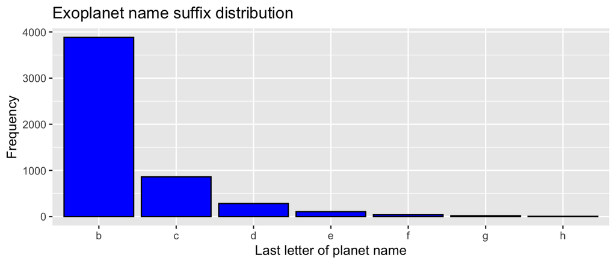

```r
ggplot(prob7, aes(x = last, y = n)) +
  geom_col(color = "black", fill = "blue") +
  xlab("Last letter of planet name") +
  ylab("Frequency") +
  ggtitle("Exoplanet name suffix distribution")
```

8. The file `wordle_data.csv` contains the original solution list to the game Wordle. In the game, players attempt to identify a secret five-letter word by guessing a word and using the color-coded information returned. A green letter from the guess is in the correct location in the secret word. A yellow letter from the guess is in the secret word, but is not in the correct location. A gray letter is not in the word (unless a guess contains multiple copis of the same letter and at least one letter is colored and another is gray).

In a puzzle, the guess information is return for these first two guesses.

- SLATE returns the pattern Gray, Gray, Gray, Yellow, Gray
- COUNT returns the pattern Yellow, Green, Gray, Gray, Yellow

*(Note that the words in the data base have all lower case letters.)*

Find all possible solutions in `wrdl` which are consistent with the information given.

*Hint: you may find it easiest to pipe the word list through multiple `filter()` commands instead of trying to create a single regular expression which only matches all possible solutions. For example, you know the secret word contains at least one `T` and this letter is not in the 4th or 5th positions, at least one `C` which is not the first letter, and that the second letter is an `O`. You also know several letters which are not contained in the secret word.*

```r
wrdl = read_csv("../../data/wordle_data.csv") %>%
  filter(solution == TRUE) %>%
  select(word)
```

#### Solution

```r
prob8 = wrdl %>%
  filter(str_count(word, "t") > 0 &
         str_count(word, "c") > 0 &
         !str_detect(word, "[slaeun]")) %>%
  filter(str_detect(word, "^[^c]o.[^t][^t]$"))

prob8
```

```
## # A tibble: 4 × 1
##   word
##   <chr>
## 1 botch
## 2 topic
## 3 torch
## 4 toxic
```

##### Erase this

```r
planets %>%
  mutate(planet_regex = str_c(str_sub(star_regex, 1, -2), " [:lower:]$")) %>%
  filter(!str_detect(planet, planet_regex))
```

```
## # A tibble: 48 × 9
##       id planet                  star  star_…¹ method  year radius  mass plane…²
##    <dbl> <chr>                   <chr> <chr>   <chr>  <dbl>  <dbl> <dbl> <chr>
##  1    12 2M0437 b                2MAS… "^2MAS… Imagi…  2021 NA     1271. "^2MAS…
##  2    13 2MASS J01033563-551556… 2MAS… "^2MAS… Imagi…  2013 NA     4132. "^2MAS…
##  3    75 CFHTWIR-Oph 98 b        CFHT… "^CFHT… Imagi…  2021 20.8   2479. "^CFHT…
##  4    78 COCONUTS-2 b            COCO… "^COCO… Imagi…  2021 12.4   2002. "^COCO…
##  5   128 EPIC 201170410.02       EPIC… "^EPIC… Trans…  2020  1.05    NA  "^EPIC…
##  6   133 EPIC 201615463 c        K2-1… "^K2-1… Trans…  2019  1.22    NA  "^K2-1…
##  7   134 EPIC 201754305 d        K2-16 "^K2-1… Trans…  2019  1.03    NA  "^K2-1…
##  8   135 EPIC 201757695.02       EPIC… "^EPIC… Trans…  2020  0.908   NA  "^EPIC…
##  9   136 EPIC 201833600 c        K2-50 "^K2-5… Trans…  2019  1       NA  "^K2-5…
## 10   138 EPIC 205950854 c        K2-1… "^K2-1… Trans…  2019  1.31    NA  "^K2-1…
## # … with 38 more rows, and abbreviated variable names ¹star_regex,
## #   ²planet_regex
```